# Statistik und Qualität - Ausarbeitung der ersten Übung

Stefan Dünser

# A) TECHNISCHE FERTIGKEITEN

## A-1) Handelt es sich bei den vorliegenden statistischen Gesamtheiten um Bestands- oder Bewegungsgrößen?

**a) Studierende an einer Hochschule.** * Bestandsgröße **b) Hochzeiten am Standesamt einer Gemeinde.** * Bewegungsgröße **c) Bei der Behörde gemeldete Personenkraftwagen.** * Bestandsgröße **d) Maschinenausfälle in einer Werkstatt.** * Bewegungsgröße **e) Wartende Kunden vor einem Abfertigungsschalter.** * Bestandsgröße

## A-2) Im Servicecenter eines Unternehmens werden über einen Zeitraum eines Tages die eingehenden Anrufe aufgezeichnet. Gezählt wird die Anzahl der pro 10-Minuten-Zeitintervall eingehenden Anrufe. Für 40 derartige Zeitintervalle erhält man folgende Ergebnisse:

```r
Liste.vec <- c(0, 0, 1, 3, 4, 1, 2, 2, 1, 1, 1, 2, 3, 0, 2, 0, 1, 3, 1, 2, 2, 0, 1, 1, 6, 1, 0, 2, 3, 1, 1, 4, 2, 3, 2, 0, 3, 0, 1, 2)
Liste.vec
```

```
##  [1] 0 0 1 3 4 1 2 2 1 1 1 2 3 0 2 0 1 3 1 2 2 0 1 1 6 1 0 2 3 1 1 4 2 3 2 0 3 0
## [39] 1 2
```

##### **a) Was stellt bei dieser Fragestellung die statistische Grundgesamtheit dar? Was sind die beobachteten Merkmale der statistischen Einheiten und wie sind sie skaliert?**

- Grundgesamtheit
  - Die Grundgesamtheit setzt sich aus den statistischen Einheiten zusammen. Die Grundgesamtheit sind die Anzahl der 10-Minuten-Zeitintervalle - (40).
- Merkmale
  - Anzahl der 10-Minuten-Zeitintervalle (40)
  - Anzahl der Anrufe über alle Zeitintervalle (65)
- Skalierung
  - Metrische Skalierung (Kardinalskala), die verhältnisskaliert ist

##### **b) Ermittle die absolute und relative Häufigkeitstabelle der eingehenden Anrufe und stelle die Häufigkeitsverteilung und Summenhäufigkeit grafisch dar.**

**Absolute Häufigkeit:**

```r
table(Liste.vec)
```

```
## Liste.vec
##  0  1  2  3  4  6
##  8 13 10  6  2  1
```

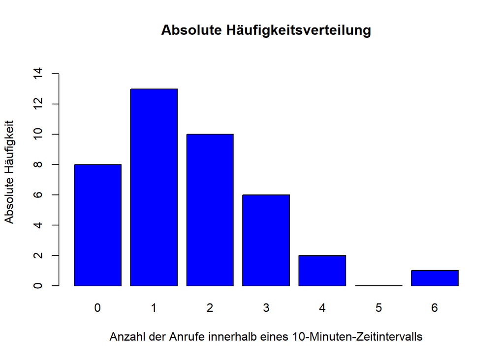

```r
barplot(table(factor(Liste.vec,levels=c(0,1,2,3,4,5,6))), ylim = c(0,15), xlab = "Anzahl der Anrufe innerhalb eines 10-Minuten-Zeitintervalls", ylab = "Absolute Häufigkeit", main = "Absolute Häufigkeitsverteilung", col = "blue")
```

**Relative Häufigkeit:**

```r
table(Liste.vec)/length(Liste.vec)
```

```
## Liste.vec
##     0     1     2     3     4     6
## 0.200 0.325 0.250 0.150 0.050 0.025
```

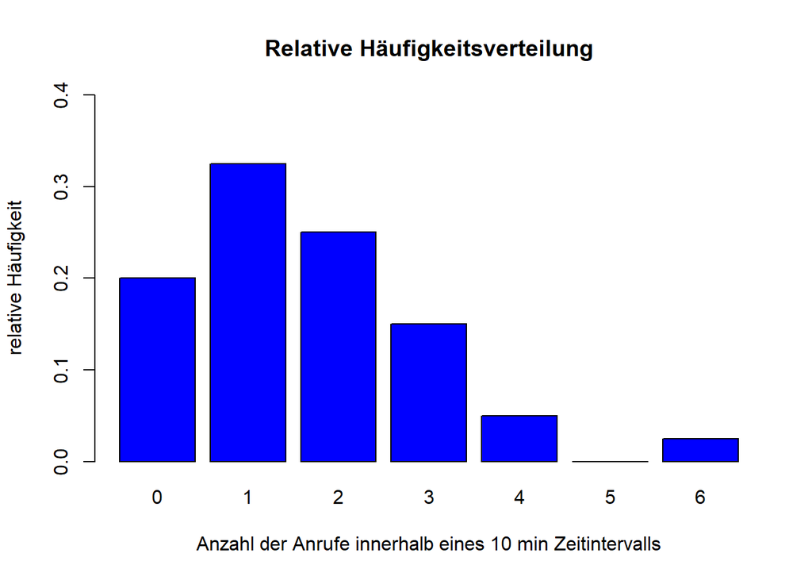

```r
barplot(table(factor(Liste.vec,levels=c(0,1,2,3,4,5,6)))/sum(table(Liste.vec)), ylim = c(0,0.4), xlab = "Anzahl der Anrufe innerhalb eines 10 min Zeitintervalls",ylab = "relative Häufigkeit", main = "Relative Häufigkeitsverteilung", col = "blue")
```

**Summenhäufigkeit**

```r
cumsum(table(Liste.vec))
```

```
##  0  1  2  3  4  6
##  8 21 31 37 39 40
```

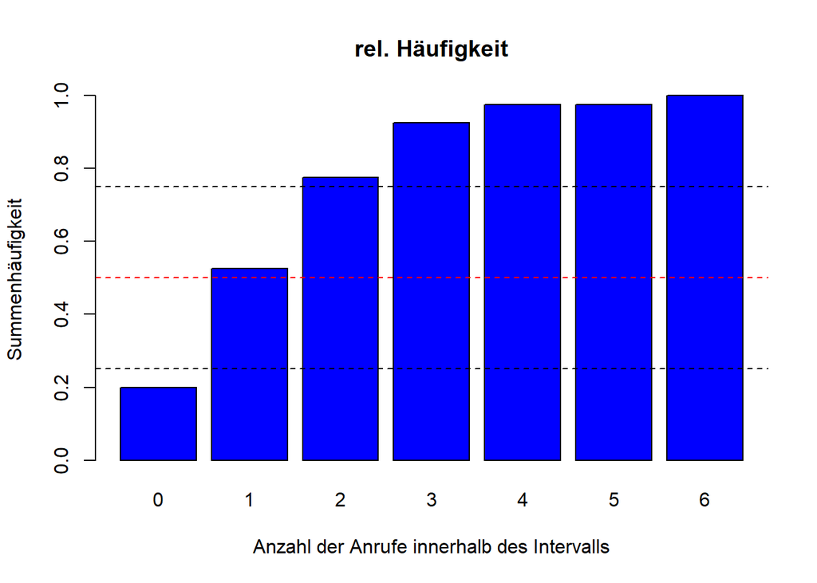

```r
barplot(cumsum(table(factor(Liste.vec,levels = c(0,1,2,3,4,5,6))))/sum(table(Liste.vec)), xlab = "Anzahl der Anrufe innerhalb des Intervalls", ylab = "Summenhäufigkeit", main = "rel. Häufigkeit", col = "blue")
abline(0.25, 0, lty = "dashed")
abline(0.5, 0, lty = "dashed", col = "red")
abline(0.75, 0, lty = "dashed")
```

*Andere Darstellung der Summenhäufigkeit*

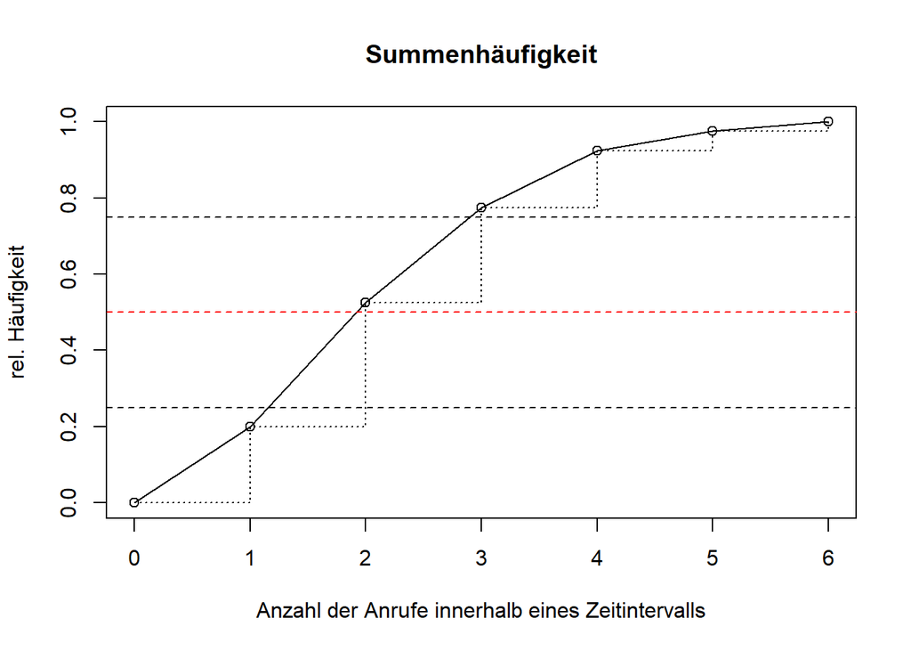

```r
Breaks.vec <- c(0:6)
SummHfk.vec <- cumsum(table(Liste.vec))/sum(table(Liste.vec))

plot(Breaks.vec, c(0,SummHfk.vec), main = "Summenhäufigkeit", xlab = "Anzahl der Anrufe innerhalb eines Zeitintervalls", ylab = "rel. Häufigkeit", type = "l", lty = 1)
points(Breaks.vec, c(0,SummHfk.vec))
lines(Breaks.vec, c(0,SummHfk.vec), type = "s", lty = 3)
abline(0.25, 0, lty = "dashed")
abline(0.75, 0, lty = "dashed")
abline(0.5, 0, lty = "dashed", col = "red")
```

##### **c) Schätze das arithmetische Mittel aus der grafischen Darstellung für die Häufigkeit und den Median aus der grafischen Darstellung für die Summenhäufigkeit.**

*Arithmetisches Mittel:* Das arithmestische Mittel kann als Schwerpunkt der Häufigkeitsverteilung angesehen werden. In diesem Fall beträgt das arithmetische Mittel nach Abschätzung rund 1,5, da somit links und rechts der x-Achse in etwa gleich viele Werte sind.  
*Median:* Der Median wird über die y-Achse ermittelt. Der Median befindet sich dann auf der x-Achse an dem Punkt, an dem 50% des y-Werts erreicht sind. In diesem Fall ist der Median bei 1.

##### **d) Berechne die möglichen Lageparameter (Zentralmaße und Streumaße)**

**Zentralmaße:**  
*Modus*

```r
getmode <- function(Liste.vec) {
   uniqv <- unique(Liste.vec)
   uniqv[which.max(tabulate(match(Liste.vec, uniqv)))]
}
mode <- getmode(Liste.vec)
mode
```

```
## [1] 1
```

*Median*

```r
median(Liste.vec)
```

```
## [1] 1
```

*Arithmetisches Mittel*

```r
mean(Liste.vec)
```

```
## [1] 1.625
```

**Streumaße:**  
*Minimum*

```r
Minimum <- min(Liste.vec)
Minimum
```

```
## [1] 0
```

*Maximum*

```r
Maximum <- max(Liste.vec)
Maximum
```

```
## [1] 6
```

*Spannweite*

```r
Spannweite <- range(Liste.vec)
Spannweite
```

```
## [1] 0 6
```

*Quantile*

```r
quantile(Liste.vec)
```

```
##   0%  25%  50%  75% 100%
##    0    1    1    2    6
```

*Mittlere absolute Abweichung*

```r
mean(abs(Liste.vec-mean(Liste.vec)))
```

```
## [1] 1.05625
```

*Standardabweichung*

```r
sd(Liste.vec)
```

```
## [1] 1.333734
```

##### **e) Stelle die Daten in einem Boxplot dar**

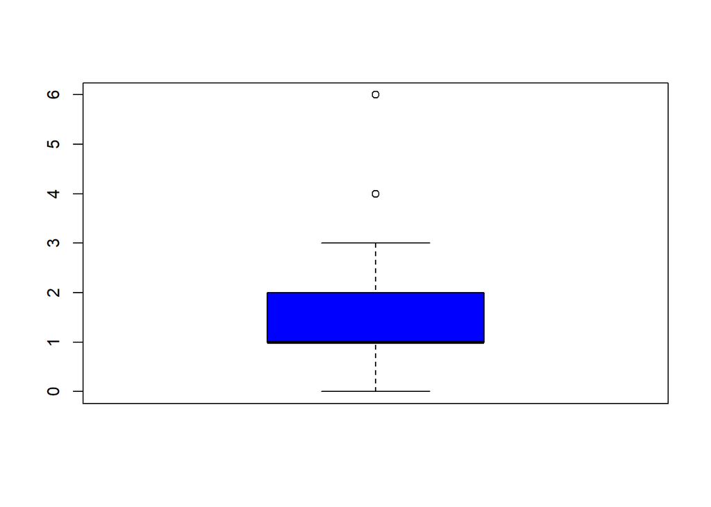

```r
boxplot(Liste.vec, col = "blue")
```

Besonders Auffällig ist bei diesem Boxplot bzw. den Werten aus der Liste, dass der Median und das erste Quartil (25% Quantil) zusammenfallen. Die Werte 4 Anrufe sowie 6 Anrufe innerhalb eines 10-Minuten_Zeitintervalls werden hier als Ausreißer aufgefasst und als Kreis dargestellt.

## A-3) Eine Anzahl von 1000 Kleinmotoren weist folgende Lebensdauer auf:

```r
Klassen.vec <- c("[0,2]", "(2,4]", "(4,6]", "(6,8]", "(8,10]")
Anzahl.vec <- c(33,276,404,237,50)

Klassen.vec; Anzahl.vec
```

```
## [1] "[0,2]"  "(2,4]"  "(4,6]"  "(6,8]"  "(8,10]"
```

```
## [1]  33 276 404 237  50
```

```r
Lebensdauer.df <- data.frame(Lebensdauer=Klassen.vec, Anzahl_Motoren=Anzahl.vec)

Lebensdauer.df
```

| Lebensdauer | Anzahl_Motoren |
| --- | --- |
| [0,2] | 33 |
| (2,4] | 276 |
| (4,6] | 404 |
| (6,8] | 237 |
| (8,10] | 50 |

*Ergänzung der vorgegebenen Liste um die Klassenbreite und die Klassenmitte*

```r
Lebensdauer.df <- data.frame(Lebensdauer=Lebensdauer.df$Lebensdauer, Klassenmitte=c(1,3,5,7,9), Klassenbreite=rep(2,5), Anzahl_Motoren=Lebensdauer.df$Anzahl_Motoren)

Lebensdauer.df
```

| Lebensdauer | Klassenmitte | Klassenbreite | Anzahl_Motoren |
| --- | --- | --- | --- |
| [0,2] | 1 | 2 | 33 |
| (2,4] | 3 | 2 | 276 |
| (4,6] | 5 | 2 | 404 |
| (6,8] | 7 | 2 | 237 |
| (8,10] | 9 | 2 | 50 |

*Ergänzung der Tabelle um die relative Häufigkeitsverteilung und die Summenhäufigkeit*

```r
RelHfgk.vec <- Lebensdauer.df$Anzahl_Motoren / sum(Lebensdauer.df$Anzahl_Motoren)

SumHfgk.vec <- cumsum(RelHfgk.vec)

Lebensdauer.df <- data.frame(Lebensdauer.df, RelHfgk.vec, SumHfgk.vec)

Lebensdauer.df
```

| Lebensdauer | Klassenmitte | Klassenbreite | Anzahl_Motoren | RelHfgk.vec | SumHfgk.vec |
| --- | --- | --- | --- | --- | --- |
| [0,2] | 1 | 2 | 33 | 0.033 | 0.033 |
| (2,4] | 3 | 2 | 276 | 0.276 | 0.309 |
| (4,6] | 5 | 2 | 404 | 0.404 | 0.713 |
| (6,8] | 7 | 2 | 237 | 0.237 | 0.950 |
| (8,10] | 9 | 2 | 50 | 0.050 | 1.000 |

*Ergänzung der Tabelle um die Häufigkeitsdichte*

```r
HfgkDichte.vec <- Lebensdauer.df$RelHfgk.vec / Lebensdauer.df$Klassenbreite

Lebensdauer.df <- data.frame(Lebensdauer.df, Dichte=HfgkDichte.vec)

Lebensdauer.df
```

| Lebensdauer | Klassenmitte | Klassenbreite | Anzahl_Motoren | RelHfgk.vec | SumHfgk.vec | Dichte |
| --- | --- | --- | --- | --- | --- | --- |
| [0,2] | 1 | 2 | 33 | 0.033 | 0.033 | 0.0165 |
| (2,4] | 3 | 2 | 276 | 0.276 | 0.309 | 0.1380 |
| (4,6] | 5 | 2 | 404 | 0.404 | 0.713 | 0.2020 |
| (6,8] | 7 | 2 | 237 | 0.237 | 0.950 | 0.1185 |
| (8,10] | 9 | 2 | 50 | 0.050 | 1.000 | 0.0250 |

##### **a) Stelle die Häufigkeitsverteilung und Summenhäufigkeit grafisch dar.**

**Absolute Häufigkeitsverteilung**

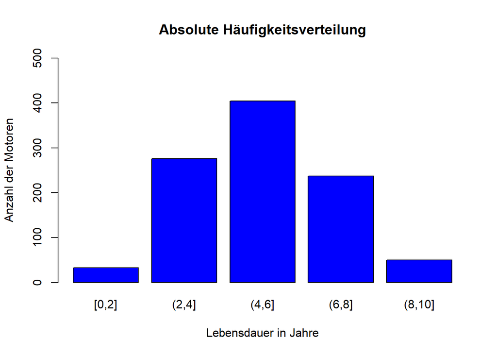

```r
barplot(Lebensdauer.df$Anzahl_Motoren, names=Lebensdauer.df$Lebensdauer, col = "blue", xlab = "Lebensdauer in Jahre", ylab = "Anzahl der Motoren", main = "Absolute Häufigkeitsverteilung", ylim = c(0,500))
```

**Relative Häufigkeitsverteilung**

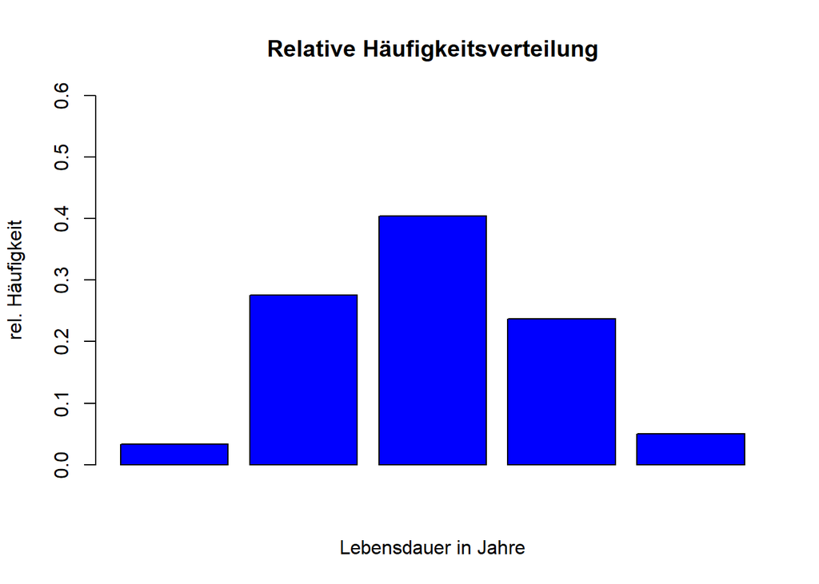

```r
barplot(Lebensdauer.df$Anzahl_Motoren / sum(Lebensdauer.df$Anzahl_Motoren), ylim = c(0,0.6), xlab = "Lebensdauer in Jahre", ylab = "rel. Häufigkeit", col = "blue", main = "Relative Häufigkeitsverteilung")
```

**Summenhäufigkeit**

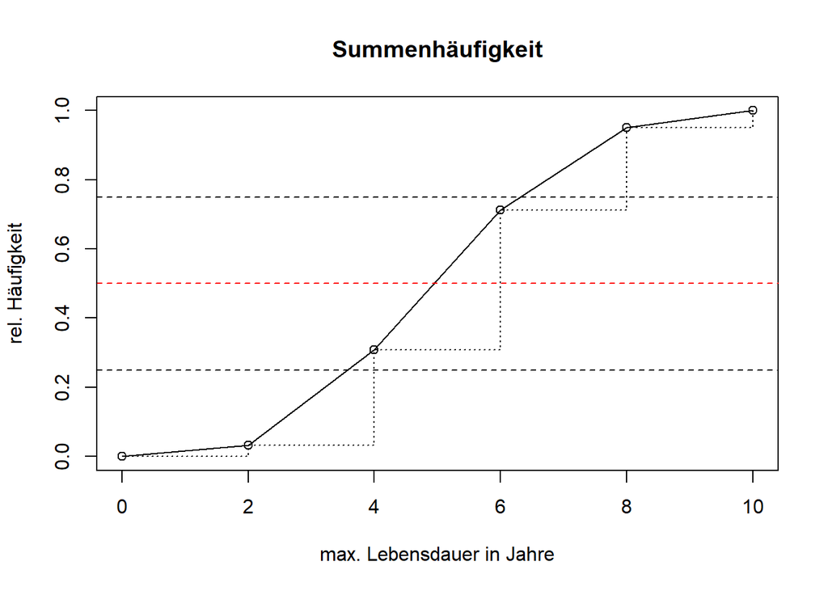

```r
X.vec <- c(0,2,4,6,8,10)
Y.vec <- c(0, Lebensdauer.df$SumHfgk.vec)
plot(X.vec, Y.vec, type = "l", lty = 1, main = "Summenhäufigkeit", xlab = "max. Lebensdauer in Jahre", ylab = "rel. Häufigkeit")
points(X.vec, Y.vec)
lines(X.vec, Y.vec, type = "s", lty = 3)
abline(0.25, 0, lty = "dashed")
abline(0.5, 0, lty = "dashed", col = "red")
abline(0.75, 0, lty = "dashed")
```

##### **b) Schätze das arithmetische Mittel aus der grafischen Darstellung für die Häufigkeit und den Median aus der grafischen Darstellung für die Summenhäufigkeit.**

*Arithmetisches Mittel - geschätzt:*  
Das arithmetische Mittel liegt bei rund 5. Beim Ablesen des arithmetischen Mittelwerts müssen links und rechts auf der x-Achse gleich viele Werte vorhanden sein.  
*Median:*  
Der Median liegt bei 50% auf der y-Achse und der Wert kann auf der x-Achse abgelesen werden. Der Median beträgt schätzungsweise bei 5.

##### **c) Bestimme der Anteil der Motoren mit über 6 Jahren Lebensdauer.**

```r
LangeLebensdauer.vec <- Lebensdauer.df$Anzahl_Motoren[4] + Lebensdauer.df$Anzahl_Motoren[5]

LangeLebensdauer.vec
```

```
## [1] 287
```

Motoren mit einer Lebensdauer über 6 Jahren befinden sich in der Liste in den letzten beiden statistischen Einheiten. Über die [] kann auf spezielle Vektorelemente/Listenelemente zugegriffen werden. In diesem Fall wird auf die Listenelemente 4 und 5 zugegriffen und für die Anzahl der Motoren, die länger als 6 Jahre laufen, addiert. Somit laufen 287 Motoren länger als 6 Jahre.  
**Lebensdauer von Motoren**

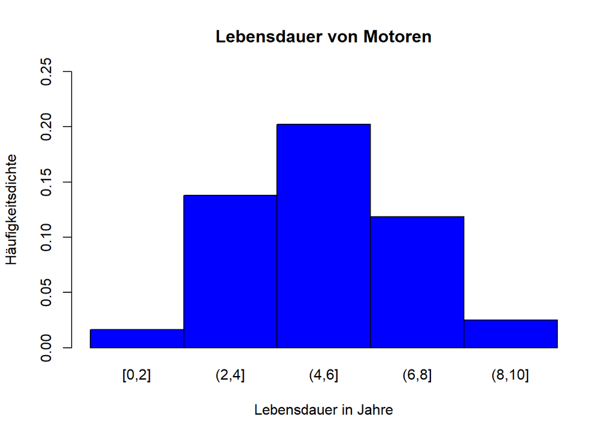

```r
barplot(Lebensdauer.df$Dichte, names=Lebensdauer.df$Lebensdauer, main = "Lebensdauer von Motoren", xlab = "Lebensdauer in Jahre", ylab = "Häufigkeitsdichte", ylim = c(0,0.25), space = 0, col = "blue")
```

##### **d) Berechne die möglichen Lageparameter (Zentralmaße und Streumaße).**

```r
Lebensdauer.vec <- c(rep(1,33), rep(3,276), rep(5,404), rep(7,237), rep(9,50))
```

**Zentralmaße:**  
*Modus*

```r
getmode <- function(Lebensdauer.vec) {
   uniqv <- unique(Lebensdauer.vec)
   uniqv[which.max(tabulate(match(Lebensdauer.vec, uniqv)))]
}
Modus <- getmode(Lebensdauer.vec)
Modus
```

```
## [1] 5
```

Der Modus wird hier duch die Zahl 5 repräsentiert. Da diese Zahl innerhalb eines Intervalls liegt, beträgt der Modus (4,6].  
*Median*

```r
median(Lebensdauer.vec)
```

```
## [1] 5
```

*Mittelwert*

```r
Mittelwert <- sum(Lebensdauer.df$RelHfgk.vec * Lebensdauer.df$Klassenmitte)

Mittelwert
```

```
## [1] 4.99
```

**Streumaße:**  
*Minimum*

```r
min(Lebensdauer.vec)
```

```
## [1] 1
```

*Maximum*

```r
max(Lebensdauer.vec)
```

```
## [1] 9
```

*Spannweite*

```r
range(Lebensdauer.vec)
```

```
## [1] 1 9
```

*Quantile*

```r
quantile(Lebensdauer.vec)
```

```
##   0%  25%  50%  75% 100%
##    1    3    5    7    9
```

*Standardabweichung*

```r
sd(Lebensdauer.vec)
```

```
## [1] 1.83937
```

*Mittlere absolute Abweichung*

```r
mean(abs(Lebensdauer.vec-mean(Lebensdauer.vec)))
```

```
## [1] 1.36182
```

In diesem Beispiel ist der Modus 5. Da es 5 Jahre Lebensdauer nicht gibt, ist die richtige Antwort, dass der Modus das einseitig offene Intervall (4,6] ist.

## A-4) Ein technisches Servicecenter zeichnet an 100 Tagen die Häufigkeit der Einsätze auf. Es ergibt sich folgende Tabelle:

```r
AnzahlTage.vec <- c(16,48,27,9)
AnzahlEinsätze.vec <- c("[0,10]", "(10,20]", "(20,30]", "(30,80]")
Service.df <- data.frame(Einsätze = AnzahlEinsätze.vec, Tage = AnzahlTage.vec)
```

```r
RelHfk.vec <- Service.df$Tage / sum(Service.df$Tage)
SumHfk.vec <- cumsum(RelHfk.vec)

Service.df <- data.frame(Service.df, relHfk = RelHfk.vec, sumHfk = SumHfk.vec)
```

```r
Service.df <- data.frame(Service.df, Klassenbreite=c(10,10,10,50), Klassenmitte=c(5,15,25,55))
```

```r
HfkDichte.vec <- Service.df$relHfk / Service.df$Klassenbreite

Service.df <- data.frame(Service.df, Dichte=HfkDichte.vec)

Service.df
```

| Einsätze | Tage | relHfk | sumHfk | Klassenbreite | Klassenmitte | Dichte |
| --- | --- | --- | --- | --- | --- | --- |
| [0,10] | 16 | 0.16 | 0.16 | 10 | 5 | 0.0160 |
| (10,20] | 48 | 0.48 | 0.64 | 10 | 15 | 0.0480 |
| (20,30] | 27 | 0.27 | 0.91 | 10 | 25 | 0.0270 |
| (30,80] | 9 | 0.09 | 1.00 | 50 | 55 | 0.0018 |

##### **a) Stelle die Häufigkeitsverteilung und Summenhäufigkeit grafisch dar.**

**Häufigkeitsverteilung**

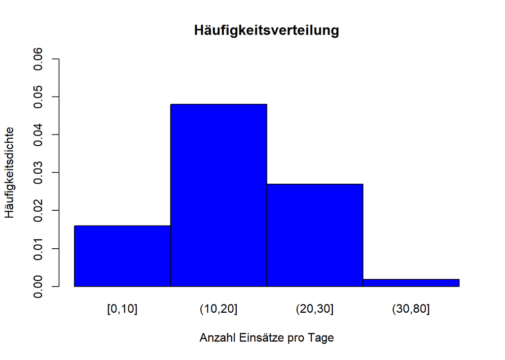

```r
barplot(Service.df$Dichte, names=Service.df$Einsätze, col = "blue", main = "Häufigkeitsverteilung", xlab = "Anzahl Einsätze pro Tage", ylab = "Häufigkeitsdichte", space = 0, ylim = c(0,0.06))
```

Die oben dargestellte Häufigkeitsverteilung bildet die statistischen Einheiten in einheitlichen Klassenbreiten ab. Die Darstellung lässt den Trugschluss zu, dass die letzte statistische Einheit die gleiche Breite wie die anderen Klassen aufweist. Im Gegensatz zu den anderen Einheiten ist die letzte statistische Einheit nicht 10 sondern 50 Einsätzte pro Tag breit. In diesem Fall entspricht die Darstellung nicht einer Häufigkeitsdichteverteilung, was auch bedeutet, dass die y-Achse nicht richtig beschriftet ist.  
In der nachfolgenden Darstellung werden die Intervalle ignoriert und die absolute Anzahl der Einsätze pro Tag angezeigt. Diese Darstellung kann einfacher verständlich und besser anschaulich zeigen, mit welcher Häufigkeit Anrufe pro Tag auftreten. Die Darstellung enstpricht auch der Häufigkeitdichtefunktion.

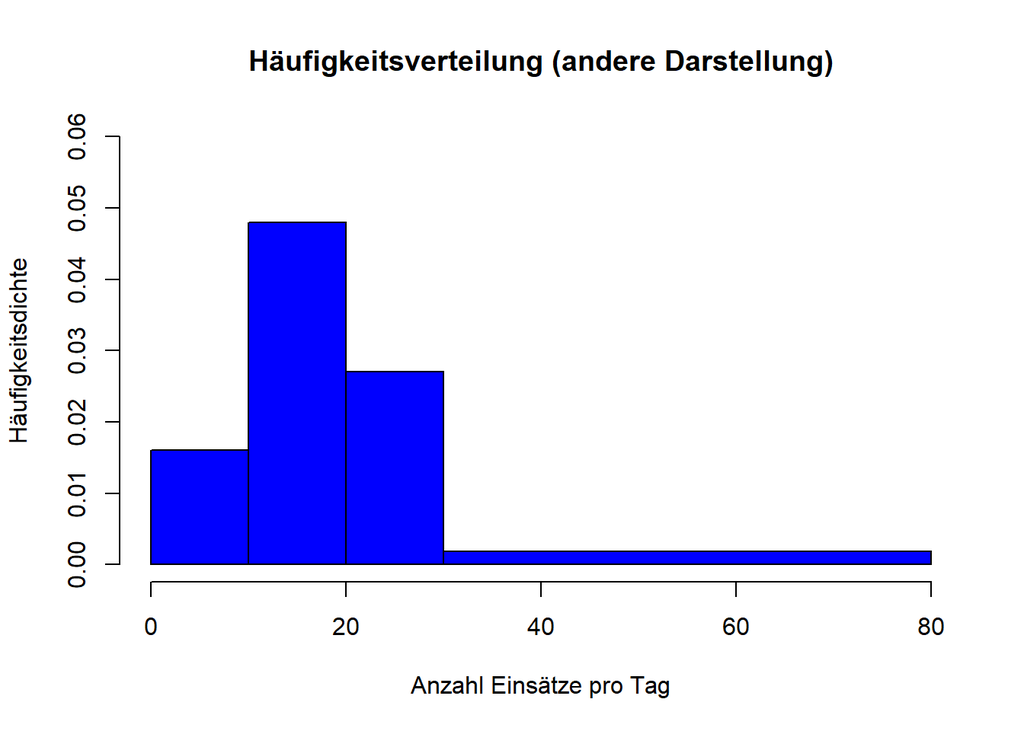

```r
Service.vec <- c(rep(5,16), rep(15,48), rep(25,27), rep(55,9))
X2a4.vec <- c(0,10,20,30,80)
hist(Service.vec, X2a4.vec, main = "Häufigkeitsverteilung (andere Darstellung)", xlab = "Anzahl Einsätze pro Tag", ylab = "Häufigkeitsdichte", col = "blue", ylim = c(0,0.06))
```

**Summenhäufigkeit**

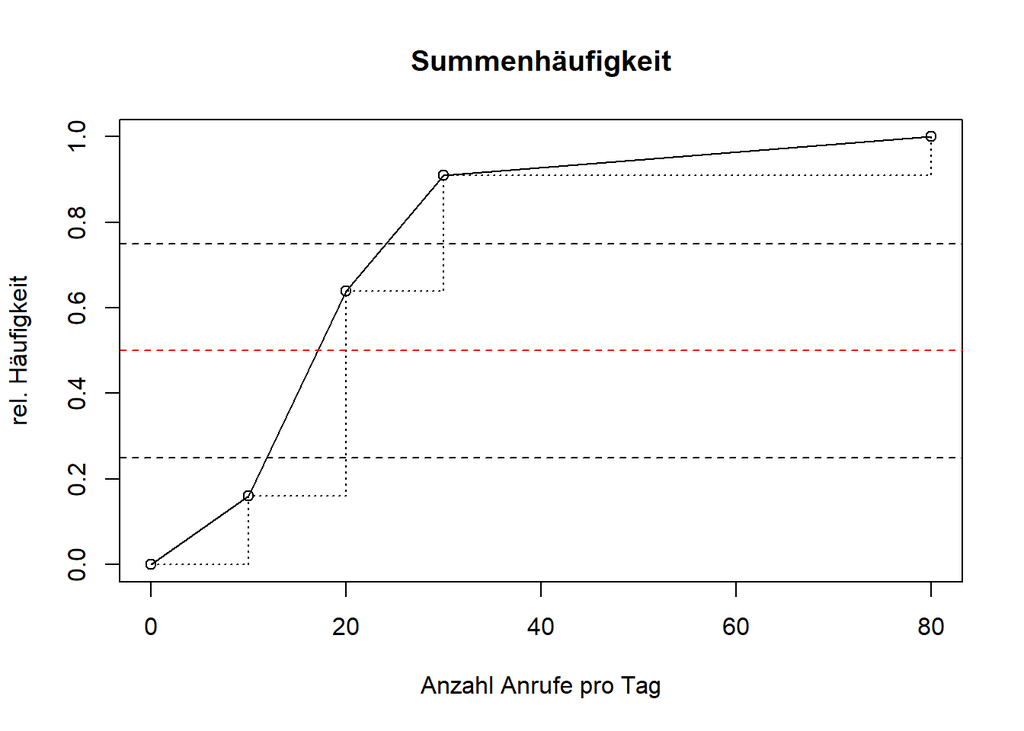

```r
Xa4.vec <- c(0,10,20,30,80)
Ya4.vec <- c(0, Service.df$sumHfk)
plot(Xa4.vec, Ya4.vec, main = "Summenhäufigkeit", xlab = "Anzahl Anrufe pro Tag", ylab = "rel. Häufigkeit", type = "l", lty = 1)
points(Xa4.vec, Ya4.vec)
lines(Xa4.vec, Ya4.vec, type = "s", lty = 3)
abline(0.25, 0, lty = "dashed")
abline(0.75, 0, lty = "dashed")
abline(0.5, 0, lty = "dashed", col = "red")
```

##### **b) Schätze das arithmetische Mittel aus der grafischen Darstellung für die Häufigkeit und den Median aus der grafischen Darstellung für die Summenhäufigkeit.**

*Arithmetisches Mittel:* Das aritmethische Mittel wird auf 19 geschätzt. Links und rechts auf der x-Achse müssen gleich viele Werte liegen, da das arithmetische Mittel den Schwerpunkt der Verteilung symbolisiert.  
*Median:* Der Median kann an der y-Achse ablesen werden. Genauer gesagt an der Stelle, an der die 50% Marke bei der relativen Häufigkeit im Summenhäufigkeitsdiagramm liegt. In diesem Fall wird der Median auf 16 geschätzt.

##### **c) Bestimme der Anteil der Tage mit über 20 Einsätzen.**

```r
Stress.vec <- Service.df$relHfk[3] + Service.df$relHfk[4]
```

Die Fragestellung verlangt nach der expliziten Angabe der Einsätze über 20 Einsätze Pro Tage. Durch Addition der relativen Häufigkeit der dritten und vierten statistischen Einheiten kann die Häufigkeit bestimmt werden, mit der mehr als 20 Einätze pro Tag absolviert werden müssen. Bei der dritten statistischen Einheit wird der Intervall mit der unteren Grenze von 20 angegeben. Eine genaue Angabe, wie häufig Tage mit über 20 Einsätzen sind, kann daher an dieser Stelle nicht gemacht werden, da ebendieses Intervall auch 20 Einsätze enthält, in der Fragestellung aber explizit nach ÜBER 20 Einsätzen gefragt wird. Ohne Rücksichtnahme auf diese Unstimmigkeit beträgt die Häufigkeit von mehr als 20 Einsätzen pro Tag rund 36 %.

##### **d) Berechne die möglichen Lageparameter (Zentralmaße und Streumaße). Welcher Aspekt könnte hier problematisch sein? Warum?**

**Zentralmaße:**  
*Modus*

```r
getmode <- function(Service.vec) {
   uniqv <- unique(Service.vec)
   uniqv[which.max(tabulate(match(Service.vec, uniqv)))]
}
getmode(Service.vec)
```

```
## [1] 15
```

*Median*

```r
median(Service.vec)
```

```
## [1] 15
```

*Mittelwert*

```r
Mittelwert <- sum(Service.df$RelHfgk.vec * Service.df$Klassenmitte)

Mittelwert
```

```
## [1] 0
```

**Streumaße:**  
*Minimum*

```r
min(Service.vec)
```

```
## [1] 5
```

*Maximum*

```r
max(Service.vec)
```

```
## [1] 55
```

*Spannweite*

```r
range(Service.vec)
```

```
## [1]  5 55
```

*Quantile*

```r
quantile(Service.vec)
```

```
##   0%  25%  50%  75% 100%
##    5   15   15   25   55
```

*Standardabweichung*

```r
sd(Service.vec)
```

```
## [1] 12.90642
```

*Mittlere absolute Abweichung*

```r
mean(abs(Service.vec-mean(Service.vec)))
```

```
## [1] 9.216
```

Die Aussagekraft des Medians für die Mitte der Daten ist für diese Datenreihe zielführender, da das arithmetische Mittel auch Ausreißer mit berücksichtigt, was beim Median nicht der Fall ist.

# B) VERSTÄNDNISFRAGEN

## B-1) Zeige, dass das arithmetische Mittel unter dem Schwerpunkt der Häufigkeitsfunktion liegt.

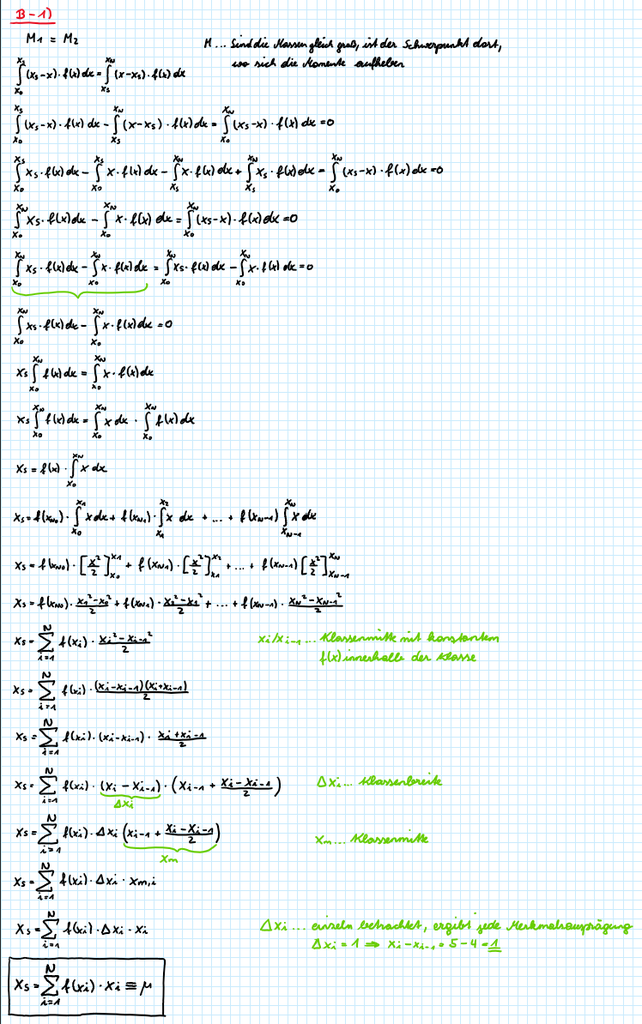

## B-2) Verschiebungssatz zur Berechnung der Standardabweichung

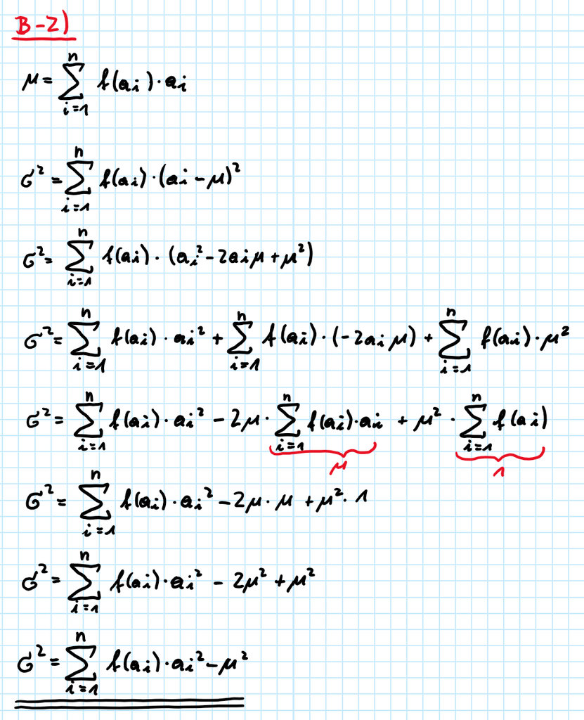

## **B-3)** Das komma-separierte File **“Fehlerquote.csv”** enthält das Prüfergebnis von 50 Bauteilen auf Funktionstüchtigkeit. Dabei steht der Eintrag **“0”** für ein fehlerfreies Bauteil und **“1”** für ein fehlerhaftes Bauteil.

```r
Fehlerquote.df <- read.csv("Fehlerquote.csv", sep = ";", dec = ",", header = TRUE)
```

##### **a) Welche Skalierung hat dieses Merkmal?**

Die Skalierung dieses Merkmals entspricht einem normalskalierten dichotomem Merkmal.

##### **b) Stelle die Messergebnisse in einer Häufigkeitstabelle und grafisch dar.**

*Häufigkeitstabelle:*

```r
Fehlerquote.vec <- table(Fehlerquote.df$fehlerhaft)/length(Fehlerquote.df$fehlerhaft)
# Spalte 1 - Zustand 0/1:
Zustand.vec <- c("fehlerfrei - 0","fehlerhaft - 1")
# Spalte 2 - rel. Häufigkeit
Fehlerhaft.vec <- sum(Fehlerquote.df$fehlerhaft)/length(Fehlerquote.df$Nr.)
RelHfkFehlerquote.vec <- c((1-Fehlerhaft.vec),Fehlerhaft.vec)

HfgTabelle.df <- data.frame(Zustand = Zustand.vec, rel.Häufigkeit = RelHfkFehlerquote.vec)
HfgTabelle.df
```

| Zustand | rel.Häufigkeit |
| --- | --- |
| fehlerfrei - 0 | 0.84 |
| fehlerhaft - 1 | 0.16 |

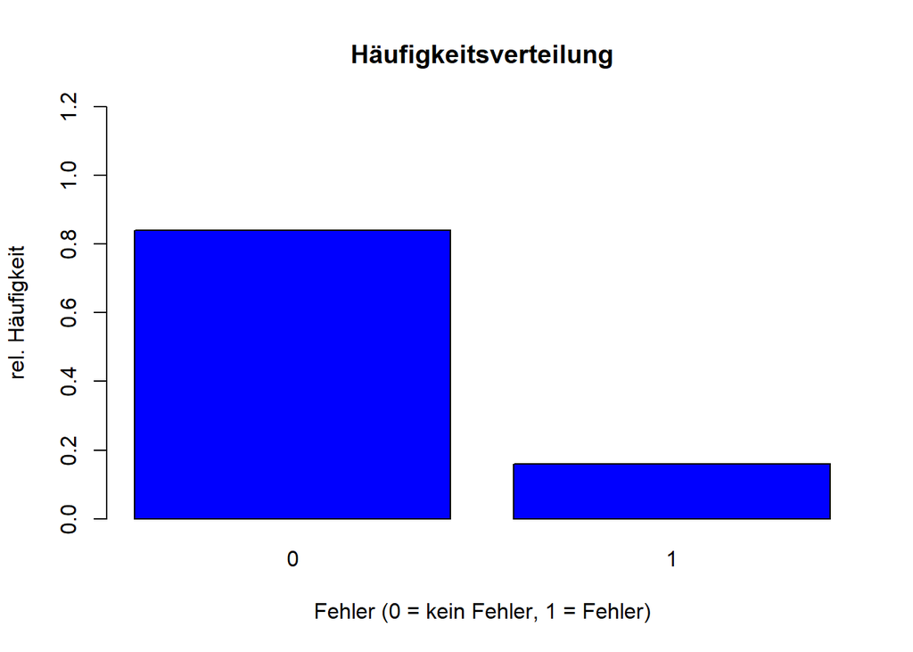

```r
barplot(Fehlerquote.vec, main = "Häufigkeitsverteilung", xlab = "Fehler (0 = kein Fehler, 1 = Fehler)", ylab = "rel. Häufigkeit", ylim = c(0,1.2), col = "blue")
```

##### **c) Wie kann man in diesem Beispiel das arithmetische Mittel berechnen und wofür steht es in diesem Fall?**

Das arithmetische Mittel gibt hier nur an, wie viele Teile fehlerhaft sind, da die Bauteile mit 0, also fehlerfreie Bauteile, nicht miteinberechnet werden.

##### **d) Wie groß ist die Standardabweichung $\sigma$? Leite eine Formel her und zeige, wie man sie in diesem Fall einfach aus dem arithmetischen Mittel errechnen kann.**

*Standardabweigung*

```r
sd(Fehlerquote.df$fehlerhaft)
```

```
## [1] 0.370328
```

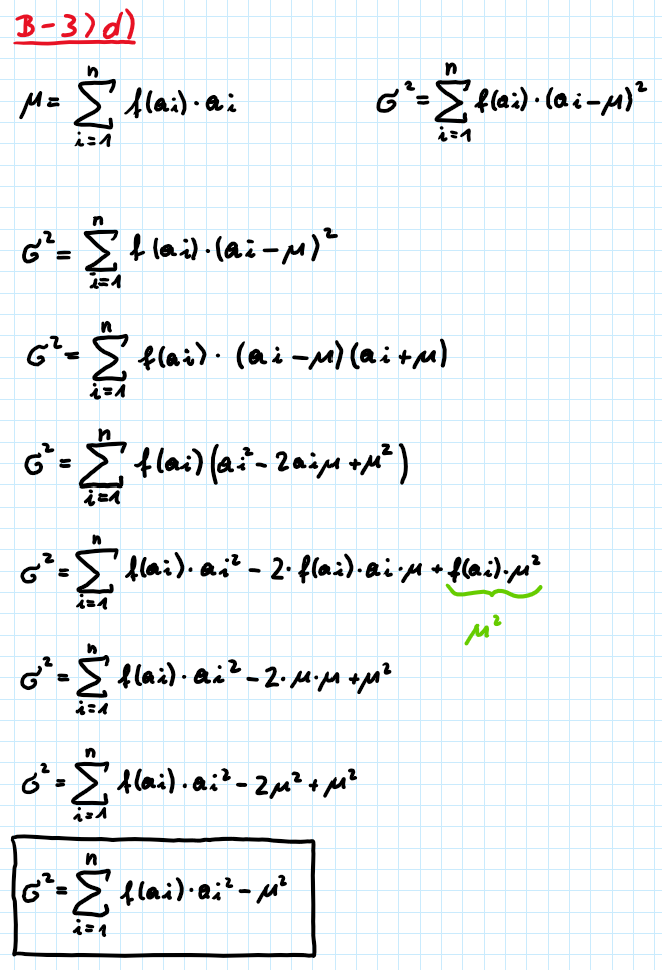

*Standardabweichung über arithmetisches Mittel*

```r
Varianz.vec <- sum((Fehlerquote.df$fehlerhaft - mean(Fehlerquote.df$fehlerhaft))^2/length(Fehlerquote.df$fehlerhaft))

Standardabweichung.vec <- sqrt(Varianz.vec)
Standardabweichung.vec
```

```
## [1] 0.3666061
```

## B-4) Das komma-separierte File **“Verteilungsvergleich.csv”** enthält in 4 Spalten die Daten von folgenden Messreihen: Ergebnis von 40 Würfeln mit einem Würfel (Annahme: gleichverteilt), die Zeitspanne (in Minuten) zwischen 40 vorbeifahrenden Autos (Annahme: exponentialverteilt), die Länge von 40 Telefongesprächen in Minuten (Annahme: normalverteilt) und die Länge von 40 Holzstiften in cm (Annahme: normalverteilt). Vergleiche die vier verschiedenen Verteilungen in den folgenden Fragen:

```r
Verteilungsvergleich.df <- read.csv("Verteilungsvergleich.csv", sep = ";", dec = ",", header = TRUE)
```

##### **a) Erstelle für jede Messreihe eine Häufigkeitstabelle sowie eine grafische Darstellung der Häufigkeitsverteilung und der Summenhäufigkeit.**

*Würfel*

```r
Würfel.df <- data.frame(Augenzahl = (1:6), abs.Häufigkeit = tabulate(Verteilungsvergleich.df$Wuerfel), rel.Häufigkeit = tabulate(Verteilungsvergleich.df$Wuerfel)/length(Verteilungsvergleich.df$Wuerfel))

Würfel.df <- data.frame(Würfel.df, Summenhfk. = cumsum(Würfel.df$rel.Häufigkeit))
Würfel.df
```

| Augenzahl | abs.Häufigkeit | rel.Häufigkeit | Summenhfk. |
| --- | --- | --- | --- |
| 1 | 5 | 0.125 | 0.125 |
| 2 | 9 | 0.225 | 0.350 |
| 3 | 7 | 0.175 | 0.525 |
| 4 | 5 | 0.125 | 0.650 |
| 5 | 8 | 0.200 | 0.850 |
| 6 | 6 | 0.150 | 1.000 |

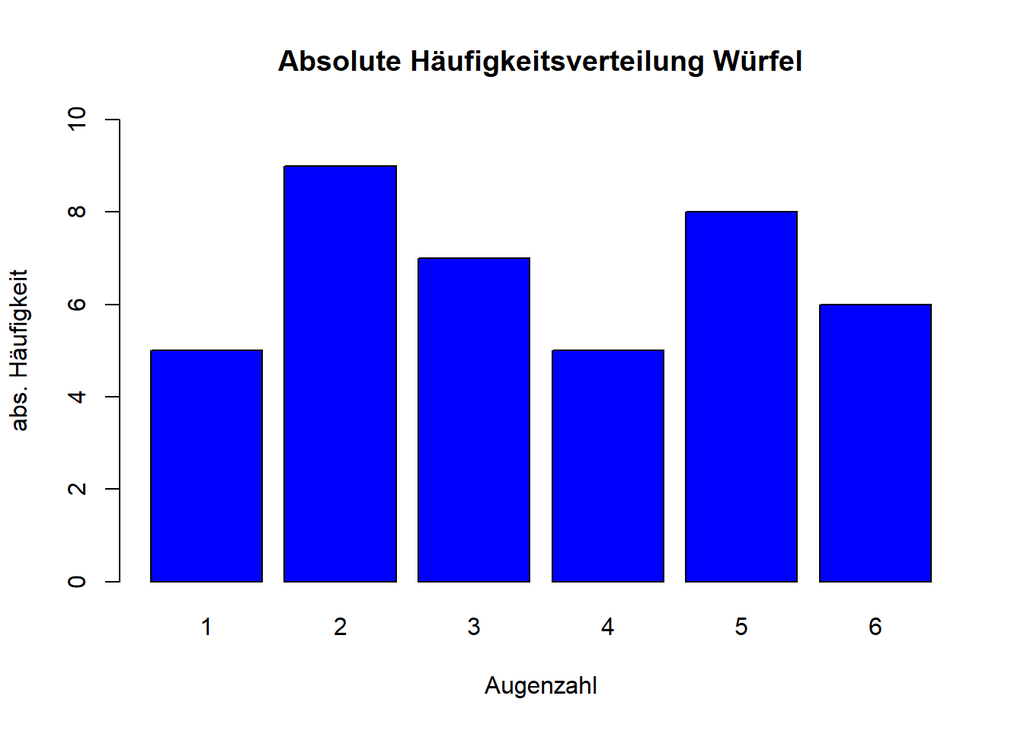

```r
barplot(Würfel.df$abs.Häufigkeit, names = Würfel.df$Augenzahl, ylim = c(0,10), main = "Absolute Häufigkeitsverteilung Würfel", xlab = "Augenzahl", ylab = "abs. Häufigkeit", col = "blue")
```

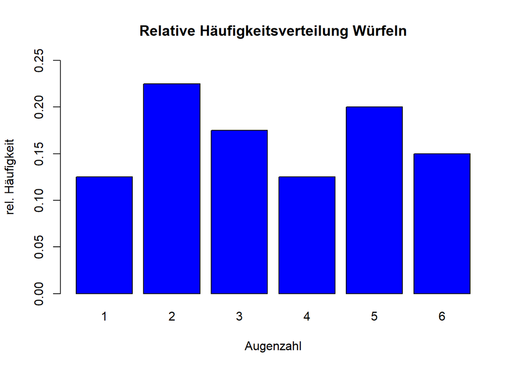

```r
barplot(Würfel.df$rel.Häufigkeit, names = Würfel.df$Augenzahl, col = "blue", main = "Relative Häufigkeitsverteilung Würfeln", xlab = "Augenzahl", ylab = "rel. Häufigkeit", ylim = c(0,0.25))
```

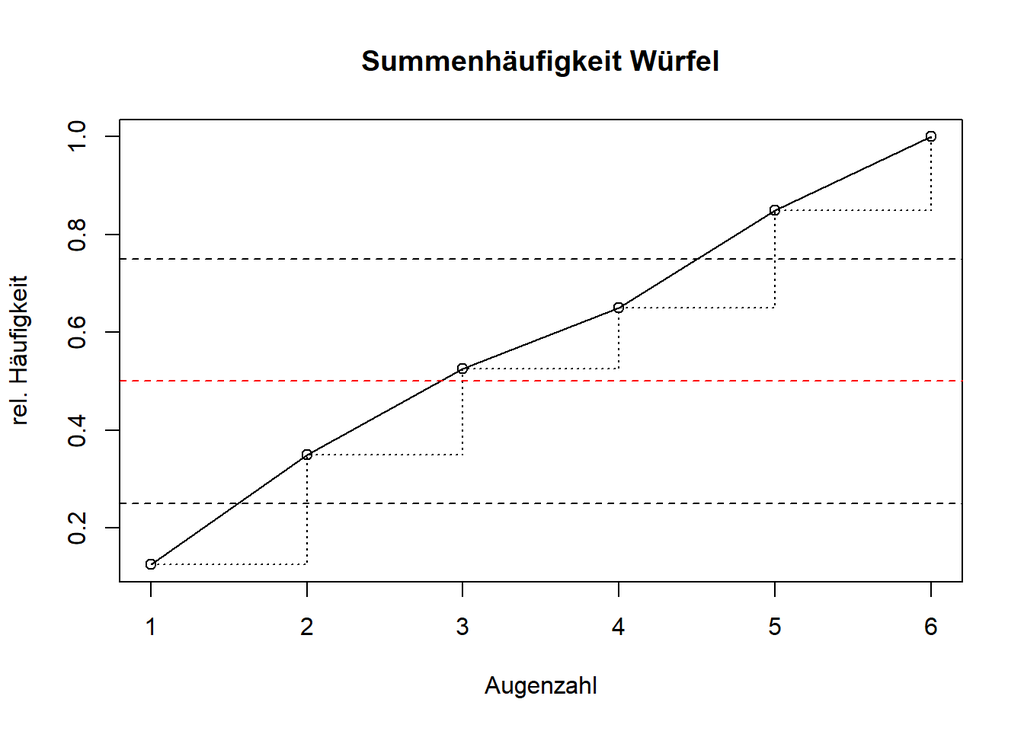

```r
plot(Würfel.df$Augenzahl, Würfel.df$Summenhfk., main = "Summenhäufigkeit Würfel", xlab = "Augenzahl", ylab = "rel. Häufigkeit", type = "l", lty = 1)
points(Würfel.df$Augenzahl, Würfel.df$Summenhfk.)
lines(Würfel.df$Augenzahl, Würfel.df$Summenhfk., type = "s", lty = 3)
abline(0.25, 0, lty = "dashed")
abline(0.75, 0, lty = "dashed")
abline(0.5, 0, lty = "dashed", col = "red")
```

*Wartezeit*

```r
Zeit.vec <- c(0,3,6,9,12,15,18)
Zeitintervalle.vec <- c("[0,3]", "(3,6]", "(6,9]", "(9,12]", "(12,15]", "(15,18]")
Klasse.vec <- tabulate(cut(Verteilungsvergleich.df$Wartezeit_min, breaks = Zeit.vec))
Wartezeit.df <- data.frame(Zeit = Zeitintervalle.vec, Klassenbreite = rep(3,6), Klassenmitte = c(1.5,4.5,7.5,10.5,13.5,16.5), abs.Häufigkeit = Klasse.vec, rel.Häufigkeit = Klasse.vec/length(Verteilungsvergleich.df$Wartezeit_min))

Wartezeit.df <- data.frame(Wartezeit.df, Summenhfk. = cumsum(Wartezeit.df$rel.Häufigkeit), Dichte = Wartezeit.df$rel.Häufigkeit/Wartezeit.df$Klassenbreite)
Wartezeit.df
```

| Zeit | Klassenbreite | Klassenmitte | abs.Häufigkeit | rel.Häufigkeit | Summenhfk. | Dichte |
| --- | --- | --- | --- | --- | --- | --- |
| [0,3] | 3 | 1.5 | 21 | 0.525 | 0.525 | 0.175000000 |
| (3,6] | 3 | 4.5 | 12 | 0.300 | 0.825 | 0.100000000 |
| (6,9] | 3 | 7.5 | 3 | 0.075 | 0.900 | 0.025000000 |
| (9,12] | 3 | 10.5 | 3 | 0.075 | 0.975 | 0.025000000 |
| (12,15] | 3 | 13.5 | 0 | 0.000 | 0.975 | 0.000000000 |
| (15,18] | 3 | 16.5 | 1 | 0.025 | 1.000 | 0.008333333 |

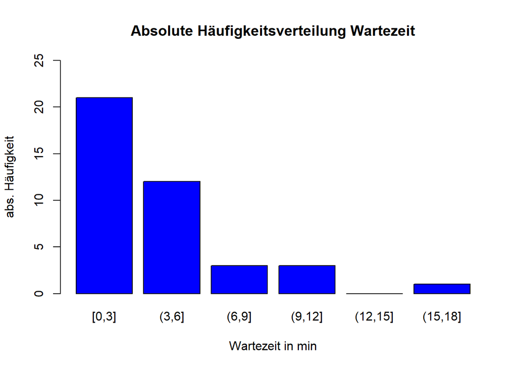

```r
barplot(Wartezeit.df$abs.Häufigkeit, names = Wartezeit.df$Zeit, main = "Absolute Häufigkeitsverteilung Wartezeit", xlab = "Wartezeit in min", ylab = "abs. Häufigkeit", col = "blue", ylim = c(0,25))
```

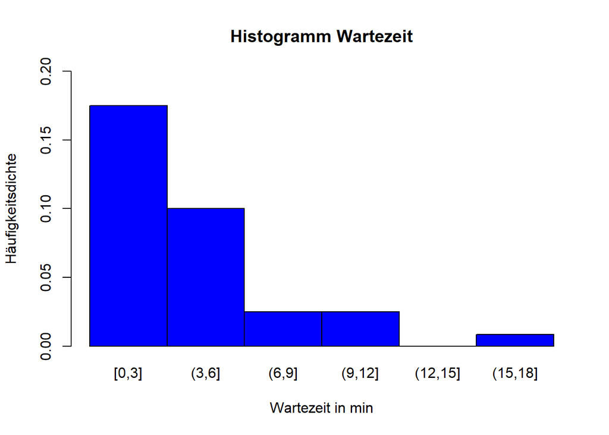

```r
barplot(Wartezeit.df$Dichte, names = Wartezeit.df$Zeit, main = "Histogramm Wartezeit", xlab = "Wartezeit in min", ylab = "Häufigkeitsdichte", space = 0, col = "blue", ylim = c(0,0.2))
```

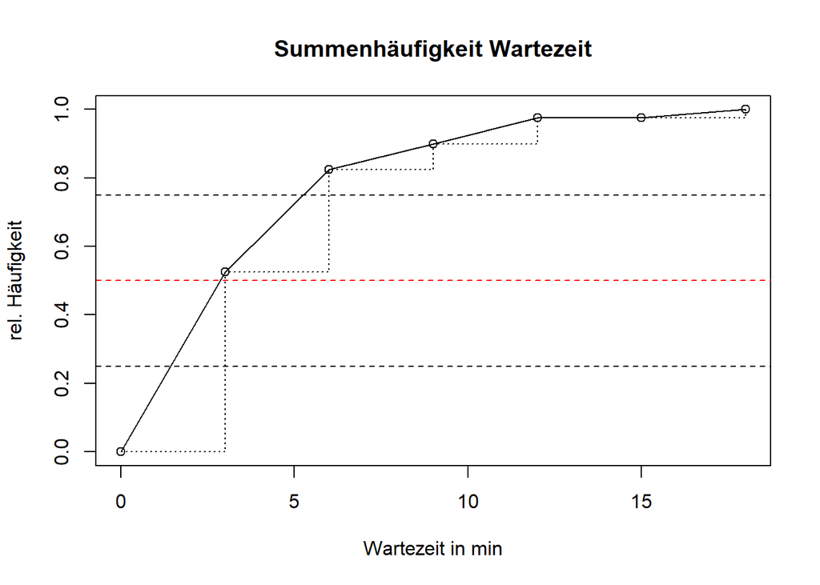

```r
plot(c(0,3,6,9,12,15,18), c(0,Wartezeit.df$Summenhfk.), main = "Summenhäufigkeit Wartezeit", xlab = "Wartezeit in min", ylab = "rel. Häufigkeit", type = "l", lty = 1)
points(c(0,3,6,9,12,15,18), c(0,Wartezeit.df$Summenhfk.))
lines(c(0,3,6,9,12,15,18), c(0,Wartezeit.df$Summenhfk.), type = "s", lty = 3)
abline(0.25, 0, lty = "dashed")
abline(0.75, 0, lty = "dashed")
abline(0.5, 0, lty = "dashed", col = "red")
```

*Telegespräche*

```r
Dauer.vec <- c(0,2,4,6,8,10,12,14,16)
Dauer_Intervall.vec <- c("[0,2]", "(2,4]", "(4,6]", "(6,8]", "(8,10]", "(10,12]", "(12,14]", "(14,16]")
Dauer_Klasse.vec <- tabulate(cut(Verteilungsvergleich.df$Telgesprae_min, breaks = Dauer.vec))
Gesprächsdauer.df <- data.frame(Gesprächsdauer = Dauer_Intervall.vec, Klassenbreite = rep(2,8), Klassenmitte = c(1,3,5,7,9,11,13,15), abs.Häufigkeit = Dauer_Klasse.vec, rel.Häufigkeit = Dauer_Klasse.vec/length(Verteilungsvergleich.df$Telgesprae_min))

Gesprächsdauer.df <- data.frame(Gesprächsdauer.df, Summenhfk. = cumsum(Gesprächsdauer.df$rel.Häufigkeit), Dichte = Gesprächsdauer.df$rel.Häufigkeit/Gesprächsdauer.df$Klassenbreite)

Gesprächsdauer.df
```

| Gesprächsdauer | Klassenbreite | Klassenmitte | abs.Häufigkeit | rel.Häufigkeit | Summenhfk. | Dichte |
| --- | --- | --- | --- | --- | --- | --- |
| [0,2] | 2 | 1 | 2 | 0.050 | 0.050 | 0.0250 |
| (2,4] | 2 | 3 | 32 | 0.800 | 0.850 | 0.4000 |
| (4,6] | 2 | 5 | 5 | 0.125 | 0.975 | 0.0625 |
| (6,8] | 2 | 7 | 0 | 0.000 | 0.975 | 0.0000 |
| (8,10] | 2 | 9 | 0 | 0.000 | 0.975 | 0.0000 |
| (10,12] | 2 | 11 | 0 | 0.000 | 0.975 | 0.0000 |
| (12,14] | 2 | 13 | 0 | 0.000 | 0.975 | 0.0000 |
| (14,16] | 2 | 15 | 1 | 0.025 | 1.000 | 0.0125 |

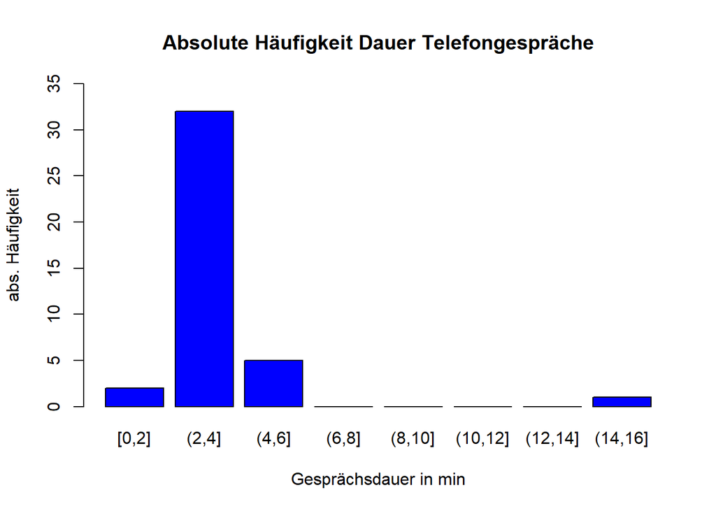

```r
barplot(Gesprächsdauer.df$abs.Häufigkeit, names = Gesprächsdauer.df$Gesprächsdauer, ylim = c(0,35), col = "blue", main = "Absolute Häufigkeit Dauer Telefongespräche", ylab = "abs. Häufigkeit", xlab = "Gesprächsdauer in min")
```

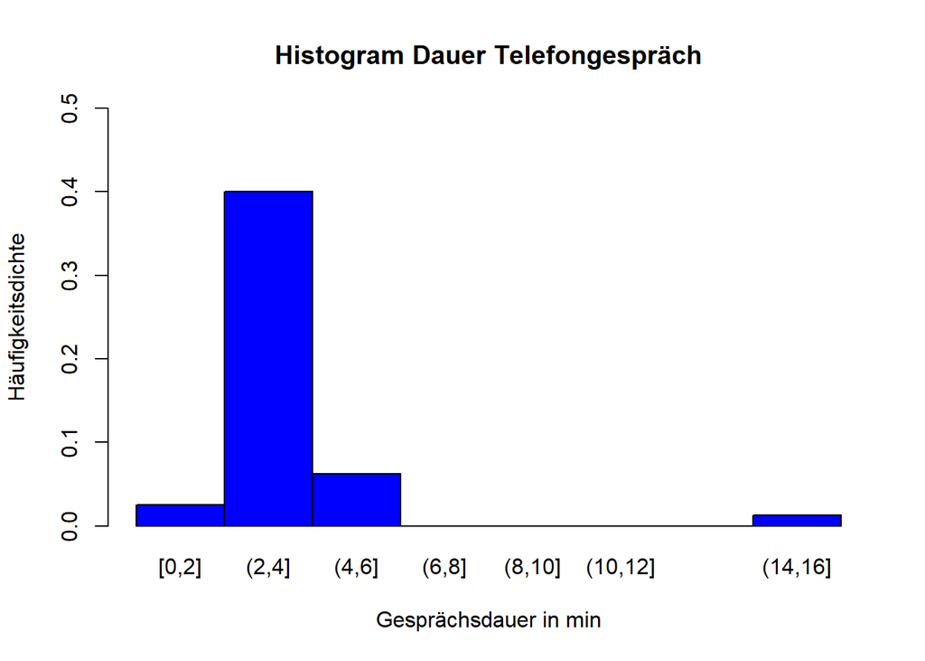

```r
barplot(Gesprächsdauer.df$Dichte, names = Gesprächsdauer.df$Gesprächsdauer, ylim = c(0,0.5), col = "blue", main = "Histogram Dauer Telefongespräch", ylab = "Häufigkeitsdichte", xlab = "Gesprächsdauer in min", space = 0)
```

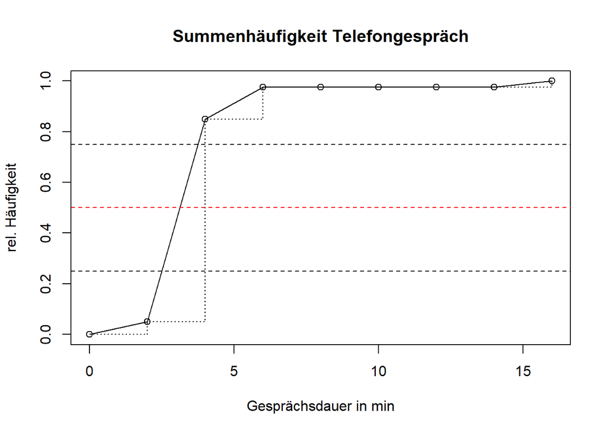

```r
plot(c(0,2,4,6,8,10,12,14,16), c(0,Gesprächsdauer.df$Summenhfk.), main =  "Summenhäufigkeit Telefongespräch", xlab = "Gesprächsdauer in min", ylab = "rel. Häufigkeit", type = "l", lty = 1)
points(c(0,2,4,6,8,10,12,14,16), c(0,Gesprächsdauer.df$Summenhfk.))
lines(c(0,2,4,6,8,10,12,14,16), c(0,Gesprächsdauer.df$Summenhfk.), type = "s", lty = 3)
abline(0.25, 0, lty = "dashed")
abline(0.75, 0, lty = "dashed")
abline(0.5, 0, lty = "dashed", col = "red")
```

*Stiftlänge*

```r
Länge.vec <- c(3.3,3.4,3.5,3.6,3.7,3.8)
Länge_Intervall.vec <- c("[3.3,3.4]", "(3.4,3.5]", "(3.5,3.6]", "(3.6,3.7]", "(3.7,3.8]")
Länge_Klasse.vec <- tabulate(cut(Verteilungsvergleich.df$Stiftlaenge_cm, breaks = Länge.vec))
Stiftlänge.df <- data.frame(Stiftlänge = Länge_Intervall.vec, Klassenbreite = rep(0.1,5), Klassenmitte = c(3.35,3.45,3.55,3.65,3.75), abs.Häufigkeit = Länge_Klasse.vec, rel.Häufigkeit = Länge_Klasse.vec/length(Verteilungsvergleich.df$Stiftlaenge_cm))

Stiftlänge.df <- data.frame(Stiftlänge.df, Summenhfk. = cumsum(Stiftlänge.df$rel.Häufigkeit), Dichte = Stiftlänge.df$rel.Häufigkeit/Stiftlänge.df$Klassenbreite)

Stiftlänge.df
```

| Stiftlänge | Klassenbreite | Klassenmitte | abs.Häufigkeit | rel.Häufigkeit | Summenhfk. | Dichte |
| --- | --- | --- | --- | --- | --- | --- |
| [3.3,3.4] | 0.1 | 3.35 | 11 | 0.275 | 0.275 | 2.75 |
| (3.4,3.5] | 0.1 | 3.45 | 8 | 0.200 | 0.475 | 2.00 |
| (3.5,3.6] | 0.1 | 3.55 | 15 | 0.375 | 0.850 | 3.75 |
| (3.6,3.7] | 0.1 | 3.65 | 5 | 0.125 | 0.975 | 1.25 |
| (3.7,3.8] | 0.1 | 3.75 | 1 | 0.025 | 1.000 | 0.25 |

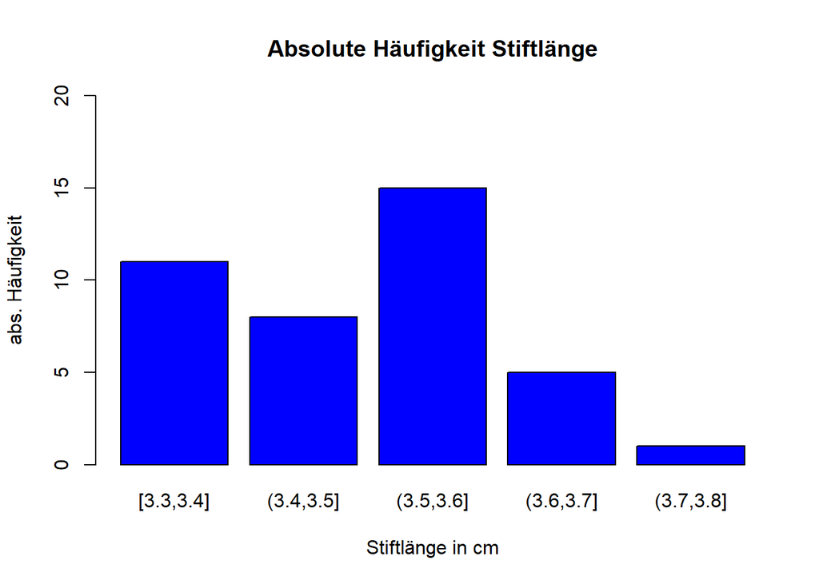

```r
barplot(Stiftlänge.df$abs.Häufigkeit, names = Länge_Intervall.vec, main = "Absolute Häufigkeit Stiftlänge", ylab = "abs. Häufigkeit", ylim = c(0,20), xlab = "Stiftlänge in cm", col = "blue")
```

Aufgrund der unglücken Wahl der Maße in cm und der geringen Steuung sowie der folglichen geringen Klassenbreite, wird hier kein Diagramm der Häufigkeitsdichte, sondern ein Diagramm der rel. Häufigkeit erstellt.

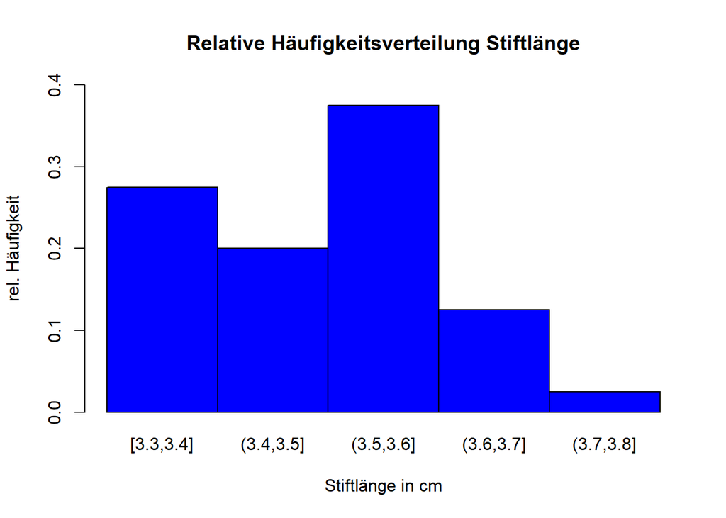

```r
barplot(Stiftlänge.df$rel.Häufigkeit, names = Länge_Intervall.vec, space = 0, col = "blue", ylim = c(0,0.4), xlab = "Stiftlänge in cm", ylab = "rel. Häufigkeit", main = "Relative Häufigkeitsverteilung Stiftlänge")
```

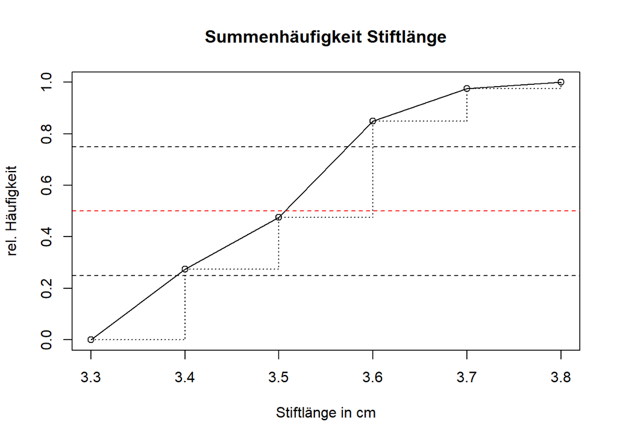

```r
plot(c(3.3,3.4,3.5,3.6,3.7,3.8), c(0,Stiftlänge.df$Summenhfk.), main = "Summenhäufigkeit Stiftlänge", xlab = "Stiftlänge in cm", ylab = "rel. Häufigkeit", type = "l", lty = 1)

points(c(3.3,3.4,3.5,3.6,3.7,3.8), c(0,Stiftlänge.df$Summenhfk.))
lines(c(3.3,3.4,3.5,3.6,3.7,3.8), c(0,Stiftlänge.df$Summenhfk.), type = "s", lty = 3)
abline(0.25, 0, lty = "dashed")
abline(0.75, 0, lty = "dashed")
abline(0.5, 0, lty = "dashed", col = "red")
```

##### **c) Bestimme für jede Messreihe jene Merkmalsausprägung, unter welcher die kleinsten 25 % zu finden sind.**

*Würfel*

```r
quantile(Verteilungsvergleich.df$Wuerfel, probs = c(0,0.25))
```

```
##  0% 25%
##   1   2
```

*Wartezeit*

```r
quantile(Verteilungsvergleich.df$Wartezeit_min, probs = c(0,0.25))
```

```
##    0%   25%
## 0.102 0.743
```

*Telefongespräche*

```r
quantile(Verteilungsvergleich.df$Telgesprae_min, probs = c(0,0.25))
```

```
##     0%    25%
## 1.6200 2.8425
```

*Stiftlänge*

```r
quantile(Verteilungsvergleich.df$Stiftlaenge_cm, probs = c(0,0.25))
```

```
##   0%  25%
## 3.34 3.40
```

##### **d) Berechne die möglichen Lageparameter (Zentralmaße und Streumaße). Versuche die Lage und die Größe der Lageparameter aufgrund der Eigenschaften der Verteilungen zu verstehen. (z.B.: Worauf deutet die verschiedenen Lage von Median und arithmetischem Mittel, wie verhält sich die Standardabweichung zu Streuparametern wie Spannweite oder Interquartilsabstand?)**

**Würfel - Zentralmaße:**  
*Modus*

```r
Modus_Wuerfel.vec <- Verteilungsvergleich.df$Wuerfel
getmode <- function(Modus_Wuerfel.vec) {
   uniqv <- unique(Modus_Wuerfel.vec)
   uniqv[which.max(tabulate(match(Modus_Wuerfel.vec, uniqv)))]
}
getmode(Modus_Wuerfel.vec)
```

```
## [1] 2
```

*Median*

```r
median(Verteilungsvergleich.df$Wuerfel)
```

```
## [1] 3
```

*Mittelwert*

```r
mean(Verteilungsvergleich.df$Wuerfel)
```

```
## [1] 3.5
```

**Würfel - Streumaße**  
*Minimum*

```r
min(Verteilungsvergleich.df$Wuerfel)
```

```
## [1] 1
```

*Maximum*

```r
max(Verteilungsvergleich.df$Wuerfel)
```

```
## [1] 6
```

*Spannweite*

```r
range(Verteilungsvergleich.df$Wuerfel)
```

```
## [1] 1 6
```

*Quantile*

```r
quantile(Verteilungsvergleich.df$Wuerfel)
```

```
##   0%  25%  50%  75% 100%
##    1    2    3    5    6
```

*Standardabweichung*

```r
sd(Verteilungsvergleich.df$Wuerfel)
```

```
## [1] 1.679438
```

*Mittlere absolute Abweichung*

```r
mean(abs(Verteilungsvergleich.df$Wuerfel-mean(Verteilungsvergleich.df$Wuerfel)))
```

```
## [1] 1.475
```

**Wartezeit - Zentralmaße:**  
*Modus*

```r
Modus_Wartezeit.vec <- Verteilungsvergleich.df$Wartezeit_min
getmode <- function(Modus_Wartezeit.vec) {
   uniqv <- unique(Modus_Wartezeit.vec)
   uniqv[which.max(tabulate(match(Modus_Wartezeit.vec, uniqv)))]
}
getmode(Modus_Wartezeit.vec)
```

```
## [1] 3.138
```

*Median*

```r
median(Verteilungsvergleich.df$Wartezeit_min)
```

```
## [1] 2.745
```

*Mittelwert*

```r
mean(Verteilungsvergleich.df$Wartezeit_min)
```

```
## [1] 3.5
```

**Wartezeit - Streumaße**  
*Minimum*

```r
min(Verteilungsvergleich.df$Wartezeit_min)
```

```
## [1] 0.102
```

*Maximum*

```r
max(Verteilungsvergleich.df$Wartezeit_min)
```

```
## [1] 15.788
```

*Spannweite*

```r
range(Verteilungsvergleich.df$Wartezeit_min)
```

```
## [1]  0.102 15.788
```

*Quantile*

```r
quantile(Verteilungsvergleich.df$Wartezeit_min)
```

```
##     0%    25%    50%    75%   100%
##  0.102  0.743  2.745  5.652 15.788
```

*Standardabweichung*

```r
sd(Verteilungsvergleich.df$Wartezeit_min)
```

```
## [1] 3.493427
```

*Mittlere absolute Abweichung*

```r
mean(abs(Verteilungsvergleich.df$Wartezeit_min-mean(Verteilungsvergleich.df$Wartezeit_min)))
```

```
## [1] 2.66165
```

**Telefongespräch - Zentralmaße:**  
*Modus*

```r
Modus_Telefongespräch.vec <- Verteilungsvergleich.df$Telgesprae_min
getmode <- function(Modus_Telefongespräch.vec) {
   uniqv <- unique(Modus_Telefongespräch.vec)
   uniqv[which.max(tabulate(match(Modus_Telefongespräch.vec, uniqv)))]
}
getmode(Modus_Telefongespräch.vec)
```

```
## [1] 3.56
```

*Median*

```r
median(Verteilungsvergleich.df$Telgesprae_min)
```

```
## [1] 3.295
```

*Mittelwert*

```r
mean(Verteilungsvergleich.df$Telgesprae_min)
```

```
## [1] 3.49975
```

**Telefongespräche - Streumaße:**  
*Minimum*

```r
min(Verteilungsvergleich.df$Telgesprae_min)
```

```
## [1] 1.62
```

*Maximum*

```r
max(Verteilungsvergleich.df$Telgesprae_min)
```

```
## [1] 14.21
```

*Spannweite*

```r
range(Verteilungsvergleich.df$Telgesprae_min)
```

```
## [1]  1.62 14.21
```

*Quantile*

```r
quantile(Verteilungsvergleich.df$Telgesprae_min)
```

```
##      0%     25%     50%     75%    100%
##  1.6200  2.8425  3.2950  3.7925 14.2100
```

*Standardabweichung*

```r
sd(Verteilungsvergleich.df$Telgesprae_min)
```

```
## [1] 1.882077
```

*Mittlere absolute Abweichung*

```r
mean(abs(Verteilungsvergleich.df$Telgesprae_min-mean(Verteilungsvergleich.df$Telgesprae_min)))
```

```
## [1] 0.8622
```

**Stiftlänge - Zentralmaße:**  
*Modus*

```r
Modus_Stiftlänge.vec <- Verteilungsvergleich.df$Stiftlaenge_cm
getmode <- function(Modus_Stiftlänge.vec) {
   uniqv <- unique(Modus_Stiftlänge.vec)
   uniqv[which.max(tabulate(match(Modus_Stiftlänge.vec, uniqv)))]
}
getmode(Modus_Stiftlänge.vec)
```

```
## [1] 3.4
```

*Median*

```r
median(Verteilungsvergleich.df$Stiftlaenge_cm)
```

```
## [1] 3.51
```

*Mittelwert*

```r
mean(Verteilungsvergleich.df$Stiftlaenge_cm)
```

```
## [1] 3.5
```

**Stiftlänge - Streumaße:**  
*Minimum*

```r
min(Verteilungsvergleich.df$Stiftlaenge_cm)
```

```
## [1] 3.34
```

*Maximum*

```r
max(Verteilungsvergleich.df$Stiftlaenge_cm)
```

```
## [1] 3.75
```

*Spannweite*

```r
range(Verteilungsvergleich.df$Stiftlaenge_cm)
```

```
## [1] 3.34 3.75
```

*Quantile*

```r
quantile(Verteilungsvergleich.df$Stiftlaenge_cm)
```

```
##   0%  25%  50%  75% 100%
## 3.34 3.40 3.51 3.57 3.75
```

*Standardabweichung*

```r
sd(Verteilungsvergleich.df$Stiftlaenge_cm)
```

```
## [1] 0.1059511
```

*Mittlere absolute Abweichung*

```r
mean(abs(Verteilungsvergleich.df$Stiftlaenge_cm-mean(Verteilungsvergleich.df$Stiftlaenge_cm)))
```

```
## [1] 0.0875
```

##### **e) Zeichne für jede Messreihe einen Boxplot**

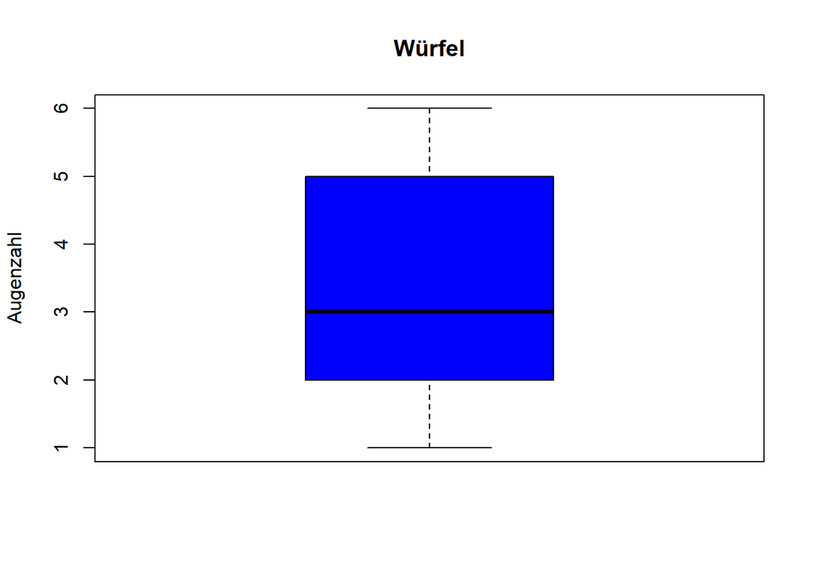

```r
boxplot(Verteilungsvergleich.df$Wuerfel, col = "blue", main = "Würfel", ylab = "Augenzahl")
```

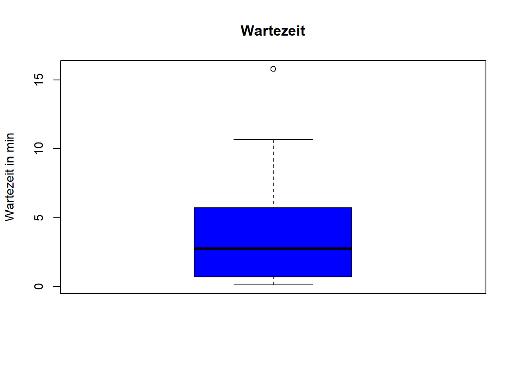

```r
boxplot(Verteilungsvergleich.df$Wartezeit_min, col = "blue", ylab = "Wartezeit in min", main = "Wartezeit")
```

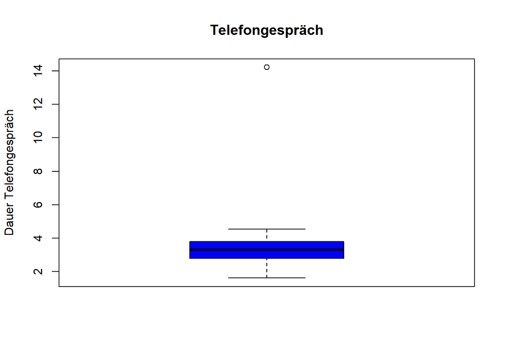

```r
boxplot(Verteilungsvergleich.df$Telgesprae_min, main = "Telefongespräch", ylab = "Dauer Telefongespräch", col = "blue")
```

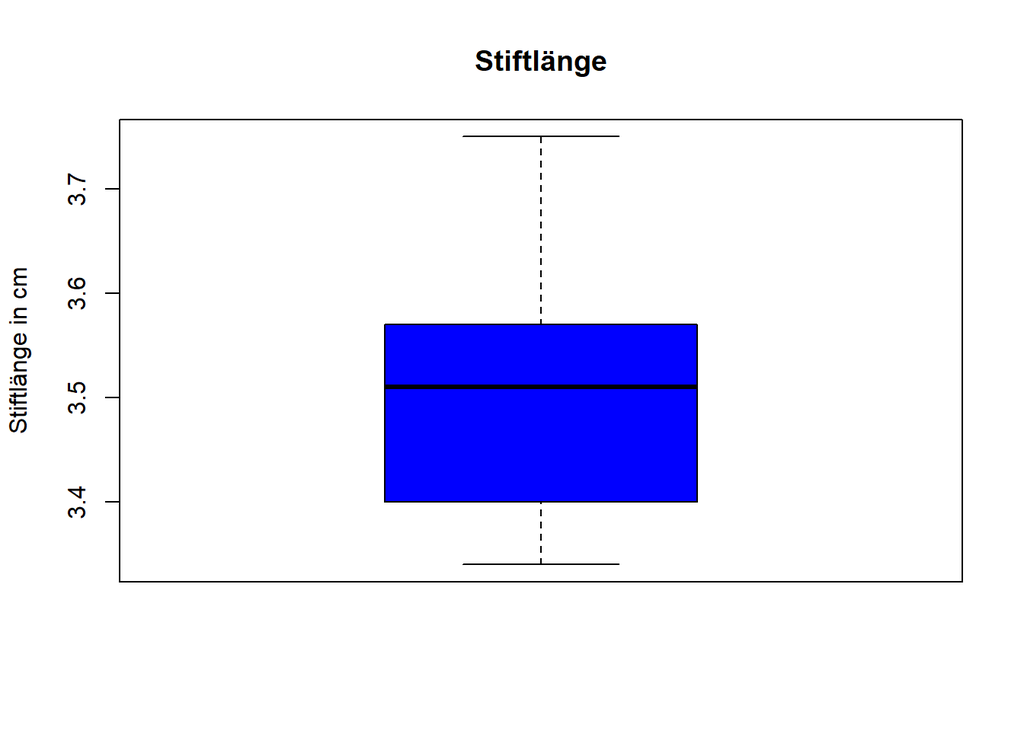

```r
boxplot(Verteilungsvergleich.df$Stiftlaenge_cm, main = "Stiftlänge", ylab = "Stiftlänge in cm", col = "blue")
```

## **B-5)** Lageparameter als Sicherheitskennzahlen. Eine Fluggesellschaft wirbt damit, dass pro 489 Millionen Passagierkilometer lediglich 1 Todesfall zu beklagen war. (Das klingt sehr gut, wenn man nur 800 km fliegen will). Mit dieser Statistik, so die Fluggesellschaft, ist die Reise mit ihr 10-mal sicherer als eine Autofahrt. (m.a.W.: Im Autoverkehr gibt es 10 Tote auf 48 Millionen Passagierkilometer, oder 1 Toten auf 4,8 Mio. Passagierkilometer.) Allerdings fliegt das Flugzeug im Durchschnitt auch 10-mal schneller als ein Auto fährt. Welche Kennzahlen würde eine Pro-Auto-Initiative dieser Werbung entgegenstellen? (Beachte die effektiven Reisezeiten.)

Wie sich aus der Statistik ableiten lässt, ist laut Fluggesellschaft das Fliegen rund 10 Mal sicherer als eine Autofahrt. Gleichzeitig wird aber auch angegeben, dass ein Flugzeug im Durchschnitt auch 10 Mal so schnell fliegt, als ein Auto fährt. Innerhalb eines gleichen Zeitabschnitts legt ein Flugzeug 48 Mio. Kilometer zurück, ein Auto hingegen nur 4,8 Mio Kilometer. Aus der Angabe geht hervor, dass für beide Strecken jeweils ein Todesopfer zu beklagen ist. Das Sterberisiko ist zwar pro Kilometer Flugstrecke geringer als pro Kilometer Autofahrt, Für eine bestimmte Reisezeit ist das Risiko zu Sterben allerdings gleich groß. Die Pro-Auto-Initiative könnte also angeben, dass pro Reisestunde das Sterberisiko bei einer Autofahrt gleich groß ist wie bei der Reise mit einem Flugzeug.

## **B-6)** Will Rogers Phänomen.

Das Will Rogers Phänomen beschreibt eine Gegebenheit, bei der durch geschicktes Verschieben von Elementen zwischen Gruppen der Mittelwert in beiden Gruppen verändert werden kann. Je nach Ausgangssituation kann dabei der Mittelwert in beiden Gruppen gesteigert oder wenn gewünscht auch verringert werden.  
Die bei dieser Untersuchtung erhobenen Daten sind alle korrekt. Durch das Zusammenlegen der Senioren und der Kinder ergeben sich für den Hersteller allerding bessere Lebensdauerergebnisse. Aufgrund der unterschiedlichen Lebenserwartung von Kindern und Jugendlichen dürfen diese nicht in derselben Gruppe ausgewertet werden.

## **B-7)** Simpsons Paradoxon.

Beim Simpson Paradoxon wird offensichtlich, dass Ergebnisse von Studien, je nach dem wie sie aufbereitet werden, völlig unterschiedliche Ergebnisse liefern, auch wenn die beiden Verfahren korrekt sind und an den Daten keine Manipulation vorgenommen wurde. So ist in diesem Beispiel ersichtlich, dass die Ergebnisse des Versuchs mit dem neuen Fertigungsverfahren einzeln betrachtet deutlich schlechter abschneidet, als bei gemeinsamer Betrachtung.  
So werden bei den zusammengefassten Ergebnissen einzelne Teile und Einzelheiten des Produktionsablaufs und Gründe für das schlechtere Abschneiden des neuen Verfahrens nicht mit berücksichtigt. Die Daten über die Durchführung bei der Studie zum neuen Produktionsverfahren werden beim Zusammenfassen also unter den Tisch fallen gelassen.  
Ein möglicher Grund für das schlechtere Abschneiden des neuen Fertigungsprozesses könnte in diesem Beispiel sein, dass die Ausschüsse nicht gleichverteilt waren, sondern am Anfang aufgrund der Umstellung viel höher ausfielen. Aus den vorliegenden Daten kann allerdings kein Rückschluss auf diese Behauptung gezogen werden. Ein weiterer Grund könnte sein, dass die Unterschiede in den beiden Werken darauf zurückgefürht werden könne, dass in den Unterschiedlichen Produktionsstätten unterschiedliche Maschinen zum Einsatz kommen. Ältere Maschinen in einem der Werke könnte z.B. dazu führen, dass der Ausschuss größer ist, da sie mit dem neuen Fertigungsverfahren nicht so gut arbeiten können.  
Zusammengefasst beschreibt das Simpson Paradoxon, dass Studienergebnisse oftmals durch “für die Studienautoren günstige Auslegung” so präsentiert werden könne, dass das Ergebnis ein anderes ist, als würde man die einzelnen Studien für sich betrachten.

## **B-8)** Studienplatz an einer Hochschule

Bei dieser Untersuchtung kommt wieder das Simpson Paradoxon zum Einsatz. Betrachtet man die Zahlen der ersten Tabelle genauer, erkennt man, dass sich deutlich mehr Studenten für einen Studienplatz an der Hochschule beworben haben als Studentinnnen. Diese Tatsache wirkt sich schlussendlich netagiv auf das Gesamtergebnis aus. In diesem Studiengang werden jeweil 10 Bewerberinnen und Bewerber aufgenommen. Die Erfolgsquote liegt bei den Bewerberinnen höher, da sich Absolut betrachtet mehr Bewerber für diesen Studienplatz gefunden haben. Auch muss berücksichtigt werden, dass der Studiengang STG-4 mit abstand am meisten Bewerberinnen und Bewerber hat, in diesem Studiengang allerdings die wenigsten Studienplätze vergeben werden. Schlüsselt man die Daten für diesen Studiengang genauer auf, wird deutlich, dass knapp 74 % aller Studentinnen sich für diesen Studiengang beworben haben. Bei den Bewerbern liegt dieser Anteil nur bei nicht einmal 53 %. Da dieser Unterschied bei der Gesamtbetrachtung vernachlässigt wird, hat es den Anschein, dass Bewerberinnen die schlechteren Chancen haben, einen Studienplatz an dieser Hochschule zu bekommen als Bewerber. Betrachtet man jedoch alle Einflussfaktoren, wie es die QM der Hochschule durch die Aufschlüsselung der Erfolgsquote auf die einzelnen Studiengäng gemacht hat, kommt man zu dem Ergebnis, dass die Chancen von Bewerberinnen höher ist als jene von Bewerbern.